# Bootstrap methods in econometrics (v. 1.1)

Prof. Gautam Tripathi (gautam.tripathi@uni.lu), practical part by Dr. Andreï V. Kostyrka (andrei.kostyrka@gmail.com)

31<sup>st</sup> March 2023

This file contains R code for showing the basis of bootstrapping of some common estimators.

```r
if (!all(c("lmtest", "sandwich") %in% rownames(installed.packages()))) install.packages(c("lmtest", "sandwich"))
```

## First steps

Assuming that the reader knows the basics of R, we show how to produce pseudo-random variables using the built-in commands.

Producing two random draws of size 10 from uniform (0, 1). Repeated calls produce different results:

```r
runif(10)
```

```
#>  [1] 0.27354 0.40842 0.01488 0.39088 0.15403 0.54153 0.17330 0.98490 0.47726
#> [10] 0.68988
```

```r
runif(10)
```

```
#>  [1] 0.11681 0.67866 0.82905 0.87153 0.91078 0.21321 0.89365 0.54535 0.74177
#> [10] 0.02956
```

Set the pseudo-random number generator (PRNG) seed to ensure replicability of your random experiments:

```r
set.seed(1)
runif(10)
```

```
#>  [1] 0.26551 0.37212 0.57285 0.90821 0.20168 0.89839 0.94468 0.66080 0.62911
#> [10] 0.06179
```

```r
set.seed(1)
runif(10)
```

```
#>  [1] 0.26551 0.37212 0.57285 0.90821 0.20168 0.89839 0.94468 0.66080 0.62911
#> [10] 0.06179
```

As you see, the output is the same because the stream of random numbers is produced from the same initial value using the same **deterministic** algorithm.

The built-in command `sample` without any argument reshuffles the input (i.e. re-samples without replacement):

```r
x <- 1:10
sample(x)
```

```
#>  [1]  3  1  5  8  2  6 10  9  4  7
```

```r
sample(x)
```

```
#>  [1]  5  9  1  6 10  7  2  4  3  8
```

We can make it reproducible by setting the seed:

```r
set.seed(1)
sample(x)
```

```
#>  [1]  9  4  7  1  2  5  3 10  6  8
```

```r
set.seed(1)
sample(x)
```

```
#>  [1]  9  4  7  1  2  5  3 10  6  8
```

Drawing 100 numbers with replacement from the empirical distribution of `x`:

```r
sample(x, size = 100, replace = TRUE)
```

```
#>   [1]  3  1  5  5 10  6 10  7  9  5  5  9  9  5  5  2 10  9  1  4  3  6 10 10  6
#>  [26]  4  4 10  9  7  6  9  8  9  7  8  6 10  7  3 10  6  8  2  2  6  6  1  3  3
#>  [51]  8  6  7  6  8  7  1  4  8  9  9  7  4  7  6  1  5  6  1  9  7  7  3  6  2
#>  [76] 10 10  7  3  2 10  1 10 10  8 10  5  7  8  5  6  8  1  3 10  3  1  6  6  4
```

To get help on this command, type `?sample`.

One can omit the argument names if they are supplied in the same order in which they go in the function definition, but this is bad practice, and this should be avoided:

```r
sample(x, 100, TRUE) # Still works
```

```
#>   [1]  9  5  1  3  6  3  7  3  3  1  9  2  8  6  1  2  7  7  4  9  8  3  5  3  4
#>  [26]  2  1  7  9 10 10  2  2  3  1  2  3  3  3  8  9  2 10  8 10  4  5  9  5  7
#>  [51]  5  6  4  2  1  3  8  9  6  1  4  5  9  5  8  4  1  9  5  1  5  4 10 10  9
#>  [76]  8  5  5  6  6  2  2  8  4 10  8  5  5  8  8  7  4  4  1 10  4  9  9  9  9
```

## Example 1: Bootstrapping the confidence interval for the mean

Suppose that we have a realisation of size 30 from a random variable from a log-normal distribution for which we want to estimate the mean and construct the 95% CI for the true mean.

```r
set.seed(1)
x <- rlnorm(30)
print(x)
```

```
#>  [1] 0.5345 1.2016 0.4336 4.9297 1.3903 0.4402 1.6281 2.0924 1.7785 0.7368
#> [11] 4.5348 1.4767 0.5373 0.1092 3.0800 0.9561 0.9839 2.5698 2.2733 1.8110
#> [21] 2.5067 2.1861 1.0774 0.1368 1.8586 0.9454 0.8557 0.2298 0.6199 1.5188
```

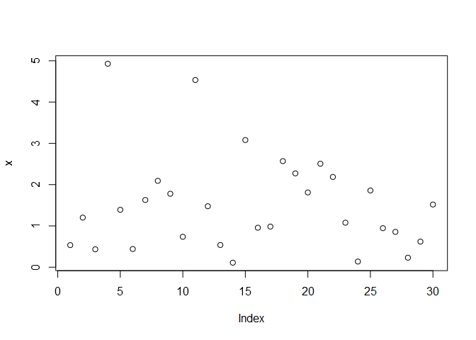

```r
plot(x)
```

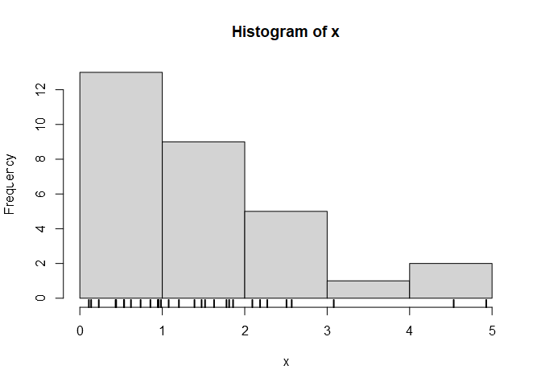

```r
hist(x)
rug(x, lwd = 2)
```

Recall that if $\mathbb{E} X = \mu$, $\mathop{\mathrm{Var}} X = \sigma^2$, then, $\bar X_n := \frac1n \sum_{i=1}^n X_i$ with $\mathbb{E} \bar X_n = \mu$ and $\mathop{\mathrm{Var}} \bar X_n = \sigma^2/n$. We use the sample average as the estimator of the mean: $\hat \mu_n := \bar X_n$. Take the unbiased consistent estimator of its variance, $\mathop{\widehat{\mathrm{Var}}} \hat\mu_n := \frac{1}{n} \mathop{\widehat{\mathrm{Var}}} X_n = \frac{1}{n} \frac{1}{n-1} \sum_{i=1}^n (X_i - \bar X_n)^2$ and $\hat \sigma_n := \sqrt{\mathop{\widehat{\mathrm{Var}}} \hat\mu_n }$. Therefore, the asymptotic symmetric 95% CI for the true mean $\mu$ is
$$\widehat{\mathrm{CI}}^\infty_{0.95} (\mu) = [\hat \mu_n +
Q_{\mathcal{N}(0, 1)}(0.025) \cdot \hat\sigma_n, \quad \hat \mu_n +
Q_{\mathcal{N}(0, 1)}(0.975) \cdot \hat\sigma_n]$$

The calculation is elementary:

```r
m <- mean(x)
s <- sd(x) / sqrt(length(x))
ci.asy <- m + s*qnorm(c(Left = 0.025, Right = 0.975))
print(c(MuHat = m, SDMuHat = s, ci.asy))
```

```
#>   MuHat SDMuHat    Left   Right
#>  1.5144  0.2139  1.0952  1.9337
```

Now, we – only as an exercise to show that this can be achieved with the core functionality without any extra packages – generate bootstrap versions of the data set `x`, compute the bootstrapped $\hat\mu^*_n$, which we aptly name `bm`, and estimate the CI as the quantiles of the bootstrap distribution:
$$\widehat{\mathrm{CI}}^\mathrm{Efron}_{0.95} (\mu) =
[Q_{\hat\mu^*_n}(0.025), Q_{\hat\mu^*_n}(0.975)]$$

```r
B <- 1000
bm <- rep(NA, B)
sort(sample(x, size = length(x), replace = TRUE)) # One bootstrap sample -- note the duplicated values
```

```
#>  [1] 0.1092 0.1092 0.1368 0.4402 0.4402 0.4402 0.4402 0.5345 0.5373 0.5373
#> [11] 0.7368 0.9561 0.9839 1.0774 1.0774 1.2016 1.4767 1.6281 1.8586 1.8586
#> [21] 2.0924 2.0924 2.0924 2.1861 2.2733 2.2733 2.2733 2.5698 4.5348 4.9297
```

```r
for (i in 1:B) {
  set.seed(i)
  xstar <- sample(x, size = length(x), replace = TRUE)
  bm[i] <- mean(xstar)
}
print(head(bm))
```

```
#> [1] 1.654 1.767 1.680 1.467 1.702 1.357
```

We can visualise the bootstrap distribution:

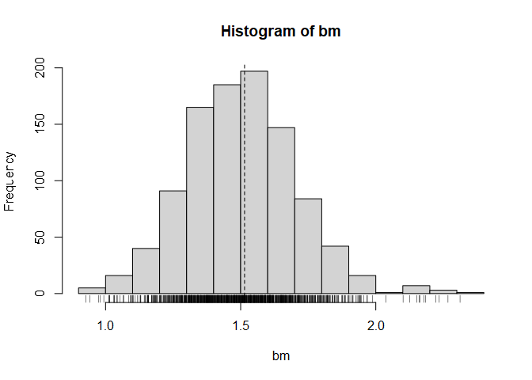

```r
hist(bm)
abline(v = m, lty = 2)
rug(bm)
```

The Efron CI is a one-liner:

```r
quantile(bm, c(0.025, 0.975))
```

```
#>  2.5% 97.5%
#> 1.117 1.916
```

Note that loops in R are to be avoided, and the quantity of interest should be computed with functions. Here is a better version of the code that calculates `bm`:

```r
bm <- sapply(1:B, function(i) {
  set.seed(i)
  xstar <- sample(x, size = length(x), replace = TRUE)
  return(mean(xstar))
})
```

## Example 2: Bootstrapping non-linear statistics

Suppose that the researcher is testing the reliability of smart bands for pulse measurement and wants to determine if the measurements obtained using the wrist of the test subjects ($X_1$) are more accurate than those obtained from the ankle ($X_2$). Usually, in such experimental settings, they attach a medical-grade monitor onto the chest to measure the true heart rate, and compute the deviations of the smart-band measurements from the chest device.

This could also be the setting popular in accounting and finance where they have two financial instruments and want to determine which one is riskier. Usually, such measures of risk are non-linear functions of the variables and/or parameters; sometimes, they are even non-smooth.

Now, consider two measures of noisiness: variance and median absolute deviation (both are widely used in empirical work; the latter is more robust and is usually applied in the cases where the distribution of $X$ is heavy-tailed). Define the population-level functionals of interest
$$\mathop{\mathrm{Var}} X := \mathbb{E}(X - \mathbb{E} X)^2, \quad
\mathop{\mathrm{MAD}} X := \mathop{\mathrm{Med}} |X -
\mathop{\mathrm{Med}} X|.$$

The statement that the wrist bands are as accurate as the ankle bands can be written as a hypothesis. In this case, we can make two hypotheses about the equality of noisiness measures. Assume that $\mathbb{E} X_1 = \mathbb{E} X_2 = 0$ and $\mathop{\mathrm{Med}} X_1 = \mathop{\mathrm{Med}} X_2 = 0$ (there is extra information that the wrist and the ankle monitors produce unbiased estimates of the true heart rate, and under-measurement is as likely as over-measurement). Then, $\mathop{\mathrm{Var}} X_i = \mathbb{E} X_i^2$ and $\mathop{\mathrm{MAD}} X_i = \mathrm{Med}| X_i|$ for $i=1,2$. The two hypotheses can be written down in a slightly simplified manner:
$$\mathcal{H}_0^{(1)}\colon \mathop{\mathrm{Var}} X_2 -
\mathop{\mathrm{Var}} X_1 \mathrel{\stackrel{\mathrm{assump.}}{=}}
\mathbb{E} X_2^2 - \mathbb{E} X_1^2 = 0 \quad \mathrm{vs.}
\quad \mathcal{H}_A^{(1)}\colon \neg\mathcal{H}_0^{(1)}$$
or
$$\mathcal{H}_0^{(2)}\colon \mathop{\mathrm{MAD}} X_2 -
\mathop{\mathrm{MAD}} X_1 \mathrel{\stackrel{\mathrm{assump.}}{=}}
\mathop{\mathrm{Med}} |X_2| - \mathop{\mathrm{Med}} |X_1| = 0 \quad
\mathrm{vs.} \quad \mathcal{H}_A^{(2)} \colon \neg\mathcal{H}_0^{(2)}$$
If $X_1$ and $X_2$ come from the same distribution, then, after one collects the data, the observed differences should be distributed around zero. However, if $X_2$ is noisier, then, the alternative is `the difference is > 0’.

Suppose that in reality, the deviations of the measurements from the true heart rate are zero-mean normal with $\sigma^2_1 = 1$ for the wrist measurement and $\sigma^2_2 = 2$ for the ankle measurement. This is how the simulated data for $n=100$ look:

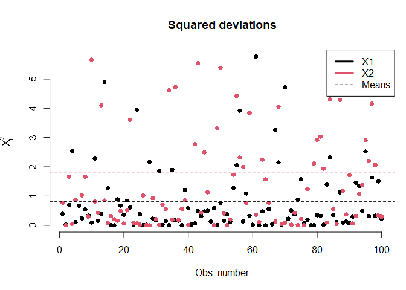

```r
set.seed(1)
x1 <- rnorm(100, 0, 1)
x2 <- rnorm(100, 0, sqrt(2))
par(mar = c(5, 4.3, 4.3, 1))
plot(x1^2, main = "Squared deviations", xlab = "Obs. number", ylab = expression(X[i]^2), pch = 16, bty = "n")
points(x2^2, col = 2, pch = 16)
abline(h = c(mean(x1^2), mean(x2^2)), lty = 2, col = 1:2)
legend("topright", c("X1", "X2", "Means"), lwd = c(3, 3, 1), col = c(1:2, 1), lty = c(1, 1, 2))
```

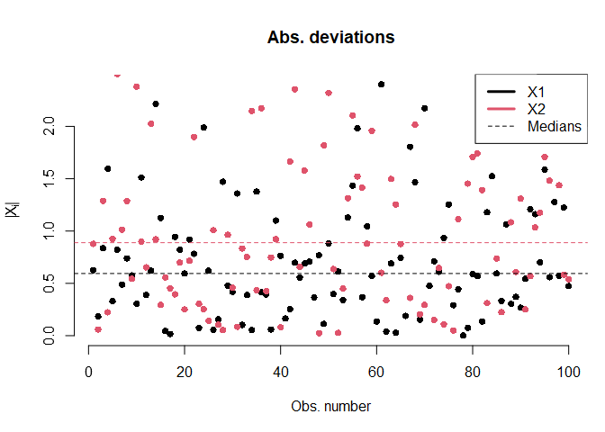

```r
plot(abs(x1), main = "Abs. deviations", xlab = "Obs. number", ylab = expression(abs(X[i])), pch = 16, bty = "n")
points(abs(x2), col = 2, pch = 16); legend("topright", c("X1", "X2"), pch = 16, col = 1:2)
abline(h = c(median(abs(x1)), median(abs(x2))), lty = 2, col = 1:2)
legend("topright", c("X1", "X2", "Medians"), lwd = c(3, 3, 1), col = c(1:2, 1), lty = c(1, 1, 2))
```

Now, what kind of conclusion can we draw about these two variables? Let us bootstrap the quantities of interest – two at once. We shall use the built-in `boot` library.

R is a functional programming language, which means that functions are invoked actions used to to anything. They may take some inputs (or nothing), and return something (or do some action or return nothing). In R, **bootstrapping requires defining a function that takes 2 arguments as input**:

1. The data from which the statistic of interest is computed (i.e. what you are bootstrapping);
2. The indices.

**The output must be the estimator computed using the data (a scalar or a vector).**

Sanity check: if `f(d, i)` is the function that one defines, then, it should internally create a bootstrapped version of the data set, `d[i, ]` (or something like this; `d[i]` if the input data are one-dimensional), and then, produce a statistic using `d[i, ]`.

In our example, we are bootstrapping $([\mathbb{E} X_2^2 - \mathbb{E} X_1^2], [\mathop{\mathrm{Med}} |X_2| - \mathop{\mathrm{Med}} |X_1|])$. Therefore, the right function would compute the differences of the sample averages and sample medians in a bootstrapped data set. We load the `boot` package first:

```r
library(boot)
```

We can check the package help or the function help like this:

```r
??boot # Get help on all the package functions
?boot # Get help on the function
```

```r
myStat <- function(data, indices) {
  var.diff <- mean(data[indices, 2]^2) - mean(data[indices, 1]^2)
  mad.diff <- median(abs(data[indices, 2])) - median(abs(data[indices, 1]))
  c(var.diff, mad.diff)
}
set.seed(1)
myboot <- boot(data = cbind(x1, x2), statistic = myStat, R = 9999)
myboot
```

```
#>
#> ORDINARY NONPARAMETRIC BOOTSTRAP
#>
#>
#> Call:
#> boot(data = cbind(x1, x2), statistic = myStat, R = 9999)
#>
#>
#> Bootstrap Statistics :
#>     original    bias    std. error
#> t1*   1.0090 -0.002243      0.2796
#> t2*   0.2949 -0.011499      0.1191
```

It is often useful to examine the structure of objects:

```r
str(myboot)
```

```
#> List of 11
#>  $ t0       : num [1:2] 1.009 0.295
#>  $ t        : num [1:9999, 1:2] 1.278 0.956 0.756 0.931 1.057 ...
#>  $ R        : num 9999
#>  $ data     : num [1:100, 1:2] -0.626 0.184 -0.836 1.595 0.33 ...
#>   ..- attr(*, "dimnames")=List of 2
#>   .. ..$ : NULL
#>   .. ..$ : chr [1:2] "x1" "x2"
#>  $ seed     : int [1:626] 10403 624 -169270483 -442010614 -603558397 -222347416 1489374793 865871222 1734802815 98005428 ...
#>  $ statistic:function (data, indices)
#>   ..- attr(*, "srcref")= 'srcref' int [1:8] 1 11 5 1 11 1 1 5
#>   .. ..- attr(*, "srcfile")=Classes 'srcfilecopy', 'srcfile' <environment: 0x0000020a93900540>
#>  $ sim      : chr "ordinary"
#>  $ call     : language boot(data = cbind(x1, x2), statistic = myStat, R = 9999)
#>  $ stype    : chr "i"
#>  $ strata   : num [1:100] 1 1 1 1 1 1 1 1 1 1 ...
#>  $ weights  : num [1:100] 0.01 0.01 0.01 0.01 0.01 0.01 0.01 0.01 0.01 0.01 ...
#>  - attr(*, "class")= chr "boot"
#>  - attr(*, "boot_type")= chr "boot"
```

So this is a list. It contains, among others, such objects as `t0` – the full-sample estimates (numeric vector), $\hat\theta_n$, i.e. `myStat(cbind(x1, x2))`, an a numeric matrix `t` with the bootstrapped statistics $\hat\theta^*_{n,b}$.

```r
print(myboot$t0) # Full-sample estimates
```

```
#> [1] 1.0090 0.2949
```

```r
head(myboot$t)
```

```
#>        [,1]     [,2]
#> [1,] 1.2780 0.509534
#> [2,] 0.9562 0.310825
#> [3,] 0.7564 0.008763
#> [4,] 0.9306 0.297211
#> [5,] 1.0570 0.357635
#> [6,] 1.2497 0.294934
```

```r
head(myboot$t[, 2])
```

```
#> [1] 0.509534 0.310825 0.008763 0.297211 0.357635 0.294934
```

This is the bootstrap variance estimator of our parameters:

```r
var(myboot$t)
```

```
#>         [,1]    [,2]
#> [1,] 0.07817 0.02330
#> [2,] 0.02330 0.01419
```

This is the Efron bootstrap CI:

```r
quantile(myboot$t[, 1], c(0.025, 0.975))
```

```
#>   2.5%  97.5%
#> 0.4671 1.5735
```

However, there are facilities to calculate other types of bootstrap-based confidence intervals using various assumptions. See the slides by Nathaniel E. Helwig (2017) at http://users.stat.umn.edu/~helwig/notes/bootci-Notes.pdf for the definitions, and Davison & Hinkley (1997) for an in-depth treatment.

To simplify bootstrap CI calculation, there is a function `boot::boot.ci`. Invoke `?boot.ci` to see the function inputs and examples. Its `index` argument indicates the coordinate of the parameter vector (i.e. the column number of `t`) for which the univariate CI is to be constructed.

```r
boot.ci(myboot, index = 1) # For the first coordinate
boot.ci(myboot, index = 2) # For the second coordinate
```

[output not shown]

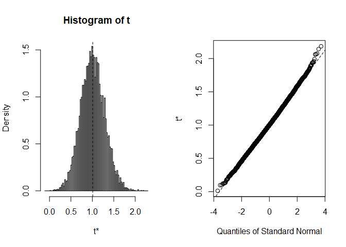

```r
plot(myboot, index = 1) # Bootstrapped mean difference of variances
```

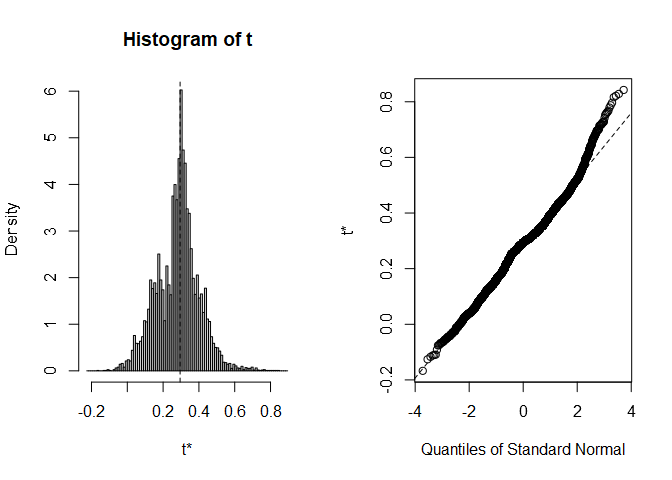

```r
plot(myboot, index = 2) # Bootstrapped median difference of abs. deviations
```

One can visualise the densities of the bootstrap estimators using any tool because we have the distribution of the $i$<sup>th</sup> coordinate of $\hat\theta_{n,1}^*, \ldots, \hat\theta_{n,B}^*$ in `myboot$t[, i]`:

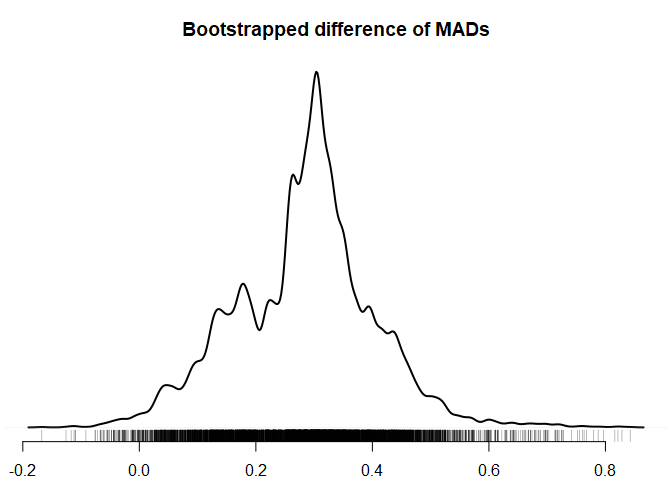

```r
par(mar = c(2, 0.2, 3, 0.2))
plot(density(myboot$t[, 2], adjust = 0.5), main = "Bootstrapped difference of MADs",
     bty = "n", yaxt =  "n", ylab = "", xlab = "", lwd = 2)
rug(myboot$t[, 2], col = "#00000088")
```

## Example 3: Bootstrapping the coefficients of a linear model

Suppose that $Y = 1 + 1\cdot X_1 + 1\cdot X_2 + \sigma(X)\cdot U_t$, $\mathbb{E}(U \mid X_1, X_2) = 0$, where $(\log X_1, \log X_2)$ are IID $\mathcal{N}(0, 1)$, $U_t \sim \mathrm{t}_6$ and $\sigma(X) := \sqrt{2 + 0.2 X_1 + \sqrt{X_2}}$ (heteroskedastic error with slightly heavy tails, as most real-life data sets have). In other words, the true parameter vector is $\theta_0 := (\beta_0, \beta_1, \beta_2) = c(1, 1, 1)$.

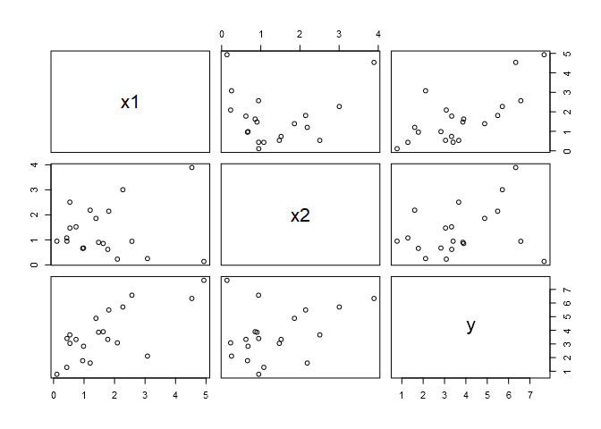

```r
genData <- function(seed = 1, n = 20) {
  set.seed(seed)
  x1 <- rlnorm(n)
  x2 <- rlnorm(n)
  s <- sqrt(2 + .2*x1 + sqrt(x2))
  y <- 1 + 1*x1 + 1*x2 + rt(n, df = 6) * s
  return(data.frame(x1, x2, y))
}
d <- genData()
plot(d)
```

This is how our data set looks like. We have only one realisation of this DGP, and suppose that we could only afford 20 observations due to the rarity of the studied phenomena. Here is how one would estimate and visualise a linear regression:

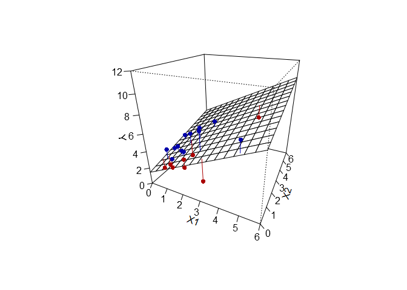

```r
mod0 <- lm(y ~ x1 + x2, data = d)
x1grid <- x2grid <- seq(0, 6, length.out = 15)
xgrid <- expand.grid(x1 = x1grid, x2 = x2grid)
yhat <- predict(mod0, newdata = xgrid)
p <- persp(x1grid, x2grid, matrix(yhat, ncol = 15), theta = 25, phi = 25,
           ticktype = "detailed", xlab = "X1", ylab = "X2", zlab = "Y", zlim = c(0, 12))
pos.resid <- d$y > mod0$fitted.values
for (i in 1:nrow(d)) lines(trans3d(rep(d$x1[i], 2), rep(d$x2[i], 2), c(mod0$fitted.values[i], d$y[i]), p),
                           col = ifelse(pos.resid[i], "#0000AA", "#AA0000"))
points(trans3d(d$x1, d$x2, d$y, p), pch = 16, col = ifelse(pos.resid, "#0000AA", "#AA0000"))
```

One could conduct inference with the estimated variance relying on the CLT (central limit theorem),
$$\sqrt{n}(\hat\theta-\theta_0) \xrightarrow[n\to\infty]{d} \mathcal{N}(0,
V_{\text{LS}}),$$
where $V_{\text{LS}} := B^{-1} M B^{-1}$ is the sandwich matrix product with ‘bread’ and ‘meat’ matrices $B := \mathbb{E}\tilde X \tilde X'$, $M := \mathbb{E} \tilde X \tilde X' U^2$. When $V_{\text{LS}}$ is estimated via $\hat V_{\mathrm{LS}} := \hat B \hat M \hat B$, in which $B$ and $M$ are replaced with sample analogues, $\hat B := n^{-1} \sum_{i=1}^n \tilde X_i \tilde X'_i$ and $\hat M := n^{-1} \sum_{i=1}^n \tilde X_i \tilde X'_i \hat U_i^2$, usually, the standard errors based on this sandwich expression under-estimate the uncertainty. This is how one computes the *t*-statistics and *p*-values relying on the estimator asymptotic normality (and finite-sample **approximate** normality):

```r
library(sandwich)
library(lmtest)
lmtest::coeftest(mod0, vcov. = function(x) sandwich::vcovHC(x, type = "HC0"))
```

```
#>
#> t test of coefficients:
#>
#>             Estimate Std. Error t value Pr(>|t|)
#> (Intercept)    1.461      0.504    2.90  0.00996 **
#> x1             1.004      0.238    4.23  0.00057 ***
#> x2             0.440      0.303    1.45  0.16511
#> ---
#> Signif. codes:  0 '***' 0.001 '**' 0.01 '*' 0.05 '.' 0.1 ' ' 1
```

However, what we never know is the **exact** finite-sample distribution of $\hat\theta_{n}$ where $n=20$. Luckily, in this simulation experiment we have the power of the oracle, and we can study the exact finite-sample distribution by generating thousands of data sets and simply computing the LS estimator on each of these data sets containing 20 points. This is what the **infeasible** distribution of $\hat\theta_{n}$ looks like, and this is what we shall be estimating by the bootstrap:

```r
MC <- 10000
trueB <- t(sapply(1:MC, function(s) {
  d <- genData(seed = s, n = 20)
  if (s %% 1000 == 0) cat(s, " / ", MC, "\n", sep = "")
  lm(y ~ x1 + x2, data = d)$coefficients
}))
```

```
#> 1000 / 10000
#> 2000 / 10000
#> 3000 / 10000
#> 4000 / 10000
#> 5000 / 10000
#> 6000 / 10000
#> 7000 / 10000
#> 8000 / 10000
#> 9000 / 10000
#> 10000 / 10000
```

It is always a good idea to add a counter to large numerical experiment so that one could know if their computer froze, or is still crunching the data.

Now we can look at the true variance of $\hat\theta_{n}$ computed by extensive oracle simulations:

```r
var(trueB) # Variance
```

```
#>             (Intercept)        x1        x2
#> (Intercept)      0.8393 -0.220710 -0.221486
#> x1              -0.2207  0.174891 -0.002979
#> x2              -0.2215 -0.002979  0.182200
```

```r
sqrt(diag(var(trueB))) # Standard deviations
```

```
#> (Intercept)          x1          x2
#>      0.9161      0.4182      0.4268
```

```r
quantile(trueB[, 2], c(0.025, 0.975)) # Confidence interval for the coefficient on X1
```

```
#>   2.5%  97.5%
#> 0.1498 1.8478
```

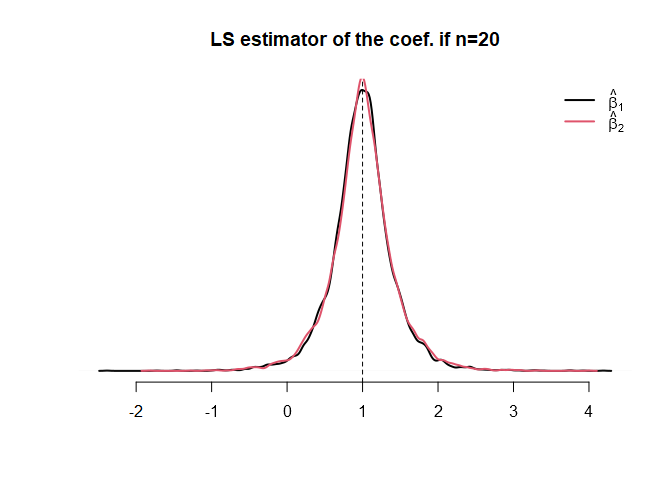

```r
plot(density(trueB[, 2], adjust = 0.75), main = "LS estimator of the coef. if n=20",
     bty = "n", xlab = "", ylab = "", yaxt = "n", lwd = 2)
lines(density(trueB[, 3], adjust = 0.75), col = 2, lwd = 2)
legend("topright", c(expression(hat(beta)[1]), expression(hat(beta)[2])), lwd = 2, col = 1:2, bty = "n")
abline(v = 1, lty = 2)
```

Now, we bootstrap the linear model for our only existing data set `d` using the pairwise bootstrap. To achieve this, we write a function that takes two arguments – data and indices – and returns the vector of coefficients:

```r
myRegCoef <- function(d, i) coef(lm(y ~ x1 + x2, data = d[i, ]))
```

In fact, this function can be applied to any data set of a similar structure to get the linear regression estimates:

```r
myRegCoef(genData(seed = 1), i = 1:20)
```

```
#> (Intercept)          x1          x2
#>      1.4609      1.0041      0.4399
```

```r
myRegCoef(genData(seed = 42, n = 200), i = 1:200)
```

```
#> (Intercept)          x1          x2
#>      0.8215      1.0396      0.9153
```

Now, we do the bootstrap:

```r
set.seed(1)
reg.boot <- boot(data = d, statistic = myRegCoef, R = 9999)
```

We can visualise the joint distribution of the slopes $(\hat\beta_1^*, \hat\beta_2^*)$:

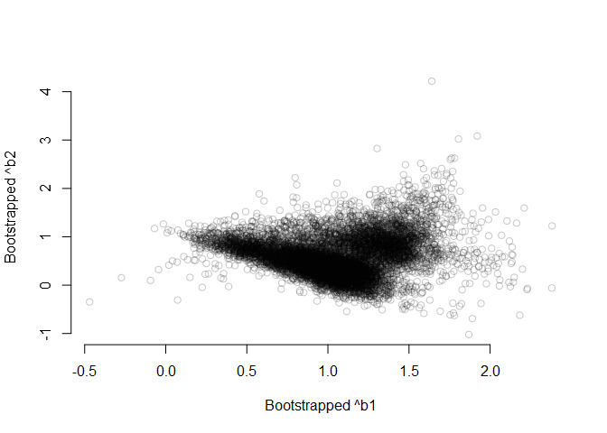

```r
plot(reg.boot$t[, 2:3], bty = "n", xlab = "Bootstrapped ^b1", ylab = "Bootstrapped ^b2", col = "#00000038")
```

This joint distribution is clearly non-Gaussian, which tells us that the asymptotic approximation might yield poor inference.

We can compare the bootstrap distribution of the second coordinate of $\hat t^*_n := (\hat\theta^*_{n} - \hat\theta_{n}) / \mathop{\mathrm{SD}}(\hat\theta^*_{n})$ with that of $\hat t_n := (\hat\theta_{n} - \theta_0) / \mathop{\mathrm{SD}}(\hat\theta_{n})$ (the former comes from bootstrap in one sample, the latter comes from a Monte-Carlo simulation in many samples):

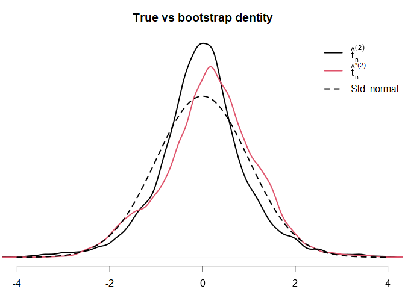

```r
par(mar = c(2, 0.2, 3, 0.2))
plot(density((trueB[, 2] - 1) / sd(trueB[, 2]), bw = 0.1), lwd = 2, xlim = c(-4, 4),
     main = "True vs bootstrap dentity", bty = "n", yaxt = "n", xlab = "", ylab = "")
lines(density((reg.boot$t[, 2] - reg.boot$t0[2]) / sd(reg.boot$t[, 2]), bw = 0.1), col = 2, lwd = 2)
curve(dnorm(x), add = TRUE, lty = 2, lwd = 2)
legend("topright", c(expression(hat(t)[n]^{(2)}), expression(hat(t)[n]^"*(2)"), "Std. normal"),
       lwd = 2, lty = c(1, 1, 2), col = c(1, 2, 1), bty = "n")
```

Now we can compare the inference with infeasible finite-sample-size-20, asymptotic, and bootstrap standard errors:

```r
lmtest::coeftest(mod0, vcov. = var(trueB)) # Infeasible
```

```
#>
#> t test of coefficients:
#>
#>             Estimate Std. Error t value Pr(>|t|)
#> (Intercept)    1.461      0.916    1.59    0.129
#> x1             1.004      0.418    2.40    0.028 *
#> x2             0.440      0.427    1.03    0.317
#> ---
#> Signif. codes:  0 '***' 0.001 '**' 0.01 '*' 0.05 '.' 0.1 ' ' 1
```

```r
lmtest::coeftest(mod0, vcov. = sandwich::vcovHC, type = "HC0") # Asymptotic; SEs too small
```

```
#>
#> t test of coefficients:
#>
#>             Estimate Std. Error t value Pr(>|t|)
#> (Intercept)    1.461      0.504    2.90  0.00996 **
#> x1             1.004      0.238    4.23  0.00057 ***
#> x2             0.440      0.303    1.45  0.16511
#> ---
#> Signif. codes:  0 '***' 0.001 '**' 0.01 '*' 0.05 '.' 0.1 ' ' 1
```

```r
lmtest::coeftest(mod0, vcov. = var(reg.boot$t)) # Better SEs
```

```
#>
#> t test of coefficients:
#>
#>             Estimate Std. Error t value Pr(>|t|)
#> (Intercept)    1.461      0.686    2.13   0.0482 *
#> x1             1.004      0.321    3.13   0.0061 **
#> x2             0.440      0.408    1.08   0.2954
#> ---
#> Signif. codes:  0 '***' 0.001 '**' 0.01 '*' 0.05 '.' 0.1 ' ' 1
```

Note that for common models, the `"HC3"` option of the `vcovHC` function yields the Davidson–MacKinnon improved leverage-adjusted VCOV estimator that yields better test sizes (asymptotically, they are all equivalent), which is an approximation of the jackknife, which is an approximation of the bootstrap:

```r
lmtest::coeftest(mod0, vcov. = sandwich::vcovHC, type = "HC3") # Quite conservative SEs
```

```
#>
#> t test of coefficients:
#>
#>             Estimate Std. Error t value Pr(>|t|)
#> (Intercept)    1.461      0.973    1.50    0.151
#> x1             1.004      0.420    2.39    0.029 *
#> x2             0.440      0.550    0.80    0.435
#> ---
#> Signif. codes:  0 '***' 0.001 '**' 0.01 '*' 0.05 '.' 0.1 ' ' 1
```

## Example 4: Bootstrap t-statistics, confidence intervals and p-values

Let us use the same data set `d` from the previous example to achieve more with bootstrap. In this example, we bootstrap pivotal $t$-statistics and conduct inference with them.

First of all, we estimate the model from the previous example via OLS and compute the standard errors in 3 easy ways: White’s asymptotic ones, White’s asymptotic times $n/(n - \dim\theta_0)$ (finite-sample correction also known as HC<sub>1</sub>), and White’s asymptotic with the Davidson–MacKinnon finite-sample correction (also known as HC<sub>3</sub>):

```r
mod0 <- lm(y ~ x1 + x2, data = d)
lmtest::coeftest(mod0, vcov. = sandwich::vcovHC(mod0, type = "HC0")) # Asymptotic
```

```
#>
#> t test of coefficients:
#>
#>             Estimate Std. Error t value Pr(>|t|)
#> (Intercept)    1.461      0.504    2.90  0.00996 **
#> x1             1.004      0.238    4.23  0.00057 ***
#> x2             0.440      0.303    1.45  0.16511
#> ---
#> Signif. codes:  0 '***' 0.001 '**' 0.01 '*' 0.05 '.' 0.1 ' ' 1
```

```r
lmtest::coeftest(mod0, vcov. = sandwich::vcovHC(mod0, type = "HC1")) # Stata finite-sample correction
```

```
#>
#> t test of coefficients:
#>
#>             Estimate Std. Error t value Pr(>|t|)
#> (Intercept)    1.461      0.546    2.67   0.0160 *
#> x1             1.004      0.258    3.90   0.0012 **
#> x2             0.440      0.329    1.34   0.1987
#> ---
#> Signif. codes:  0 '***' 0.001 '**' 0.01 '*' 0.05 '.' 0.1 ' ' 1
```

```r
lmtest::coeftest(mod0, vcov. = sandwich::vcovHC(mod0, type = "HC3")) # Leverage-based finite-sample correction
```

```
#>
#> t test of coefficients:
#>
#>             Estimate Std. Error t value Pr(>|t|)
#> (Intercept)    1.461      0.973    1.50    0.151
#> x1             1.004      0.420    2.39    0.029 *
#> x2             0.440      0.550    0.80    0.435
#> ---
#> Signif. codes:  0 '***' 0.001 '**' 0.01 '*' 0.05 '.' 0.1 ' ' 1
```

There is some ambiguity about the significance of the coefficient on $X_1$: is it highly significant, or barely significant? The asymptotic $p$ value is 50 times smaller than the one with the HC<sub>3</sub> finite-sample correction. Which one should we trust? Are there any other aspects of the sampling distribution of $\hat\theta_{n}$ that we should be aware of when conducting inference?

A simple approach would be checking whether the confidence interval contains the zero (if the zero belongs to the $100(1-\alpha)\%$ CI, then, the null hypothesis about equality to zero is not rejected at the level $\alpha$).

Computing the four types of bootstrap CIs for $\theta^{(1)}$ using the function `myRegCoef` that we introduced in the previous example (check `?boot::boot.ci` for more info):

```r
B <- 1999
set.seed(1)
system.time(boot0 <- boot::boot(data = d, statistic = myRegCoef, R = B))
```

```
#>    user  system elapsed
#>    1.33    0.00    1.33
```

```r
print(boot::boot.ci(boot0, index = 2))
```

[output not shown]

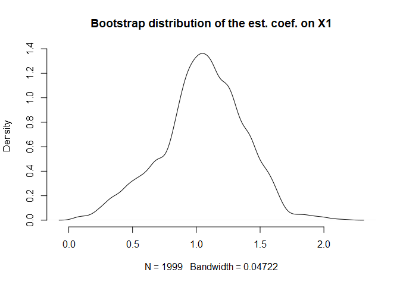

```r
plot(density(boot0$t[, 2], adjust = 0.8), main = "Bootstrap distribution of the est. coef. on X1", bty = "n")
```

Ordinary bootstrap offers no improvement in terms of the asymptotic error: for many statistics, bootstrap CIs are merely a substitution of the expensive human time with cheap machine time or a last resort if the asymptotic expressions are too complicated.

However, for smooth-function models, there exist asymptotic refinements that reduce the order of the approximation error in some aspects of inference from $O(1/\sqrt{n})$ to $O(1/n)$. The key to unlocking these accuracy gains is bootstrapping **asymptotically pivotal statistics**, i.e. those that do not depend on the underlying distribution. In other words, if you know that as $n\to\infty$, the distribution function $\mathrm{CDF}_{\hat\theta_n(\mathbb{P}_Z)}(u)$ does not depend on $\mathbb{P}_Z$ and can be simply expressed as $F(u)$, then, such a statistic is pivotal. The pivotality depends on the aspect that you are testing: for testing hypotheses about the mean of the population, the $t$-statistic is pivotal because it converges in distribution to $\mathcal{N}(0, 1)$. The $t$ test for the GMM coefficient is asymptotically pivotal (normal distribution). The Wald test is pivotal as well ($\chi^2_k$). In fact, if $\hat\theta_n$ is pivotal, then, the accuracy of the bootstrap for estimating the symmetrical distribution function $F(U) := \mathrm{Prob}(|\hat\theta_n| \le u)$ is even higher, with the error of order $O(1/n^2)$!

However, constructing a pivotal statistic comes at a cost: we have $\hat\theta^*_{1,n}, \ldots, \hat\theta^*_{B,n}$, and to construct a pivotal *t*-statistic from it, we need
$$\frac{\hat\theta^*_{1,n} -
\hat\theta_n}{\widehat{\mathrm{SE}}(\hat\theta^*_{1,n})}, \ldots,
\frac{\hat\theta^*_{B,n} -
\hat\theta_n}{\widehat{\mathrm{SE}}(\hat\theta^*_{B,n})}
\xrightarrow[n\to\infty]{d} \mathcal{N}(0, 1).$$

Question: how to obtain $\widehat{\mathrm{SE}}(\hat\theta^*_{b,n})$? There are at least 3 ways to answer this question:

1. Bootstrapping the bootstrap;
2. Computing the asymptotic $\widehat{\mathrm{Var}} (\hat\theta^*_{b,n})$ using just $\mathcal{Z_{b,n}^*}$;
3. Jackknife (will not be shown in this note).

Once we estimate the variance of $\hat\theta^*_{b,n}$, we compute the standard error and the $t$-statistic for each bootstrap replication, and the latter allows us to conduct better (e.g. in terms of the test size, among other aspects) inference.

### Approach 1: bootstrapping the bootstrap

In this approach, we treat the bootstrap sample $\mathcal{Z}^*_{b,n}$ as the original population, treat $\hat\theta^*_{b,n}$ as the full-sample estimator, and re-sample from $\mathcal{Z}^*_{b,n}$ to get $\mathcal{Z}^{**}_{b,1,n}, \ldots, \mathcal{Z}^{**}_{b,C,n}$, where $C$ is the number of replications in the inner bootstrap.

To answer these questions, we implement nested bootstrap. It is computationally much more intensive, which is why we are using a slightly lower number of internal bootstrap replications.

The function `myRegCoef` returns $\hat\theta^*_n$ (length 3); the function `bootCoefT` returns $(\hat\theta^*_n, \widehat{\mathrm{Var}}^* {\hat\theta^*_n})$ (length 3 + 3 = 6). The function `bootCoefT` subsumes `myRegCoef`, but takes longer to run. With equal input data and indices, the output of `myRegCoef` is identical to the first 3 elements of the output of `bootCoefT`:

```r
bootCoefT <- function(d, i, C = 999) {
  dstar <- d[i, ]
  theta0 <- myRegCoef(dstar, 1:nrow(d))
  thetastar <- boot::boot(data = dstar, statistic = myRegCoef, R = C)
  varstar <- diag(var(thetastar$t))
  c(theta0, varstar)
}
```

Before running the computationally intensive bootstrap, we measure the time for one replication:

```r
system.time(bootCoefT(d, 1:nrow(d)))
```

```
#>    user  system elapsed
#>    0.59    0.00    0.59
```

At the time of writing, most computers spend roughly 0.7 s on one replication, which implies that 2000 replications will take half an hour, which is very annoying, especially for a linear regression with 2 regressors and 20 observations. Therefore, parallelising is the only way to same time; **the next chunk is expected to take 7 minutes**.

On anything **not running Windows** (Mac or Linux), a couple of extra arguments to `boot::boot()` for parallelisation through a *fork cluster* works like a charm. However, on Windows, it cannot use more than 1 core (no fork support), and extra steps are necessary to speed up the extremely slow computations.

If one has to work on a Windows machine with no alternative and one still wants to used the `boot::boot` interface with parallelism, then, one has to go through a rather cumbersome procedure. One needs to (1) create a *PSOCK cluster*, (2) export all the functions and objects from the global environment if the function that computes the statistic relies on them, (3) re-specify the number of cores again, and (4) stop the cluster when the parallel computations finish running. This is one of the reasons why 0 out of world’s top 500 supercomputers use Windows. The University of Luxembourg is running Linux in the cluster for the same reason: better for efficient computations, less hassle, proper parallelisation support, actual process forking and no need to re-export the environment objects.

```r
cores <- 4 # Change to the number of *PHYSICAL* (not logical) cores on your machine
# Work laptops usually have 4; gaming laptops, 6; 12th-gen i7 Intel, 14
```

**Hint:** open the Task Manager, Resource Monitor, `htop` or any other CPU monitoring tool to check if the load is taken up by multiple cores!

The following code will detect the OS type and run the appropriate version. Of course a PSOCK cluster will work on Mac and Linux, but in most cases, fork clusters are easier to work with.

```r
if (.Platform$OS.type == "windows") {
  cl <- parallel::makeCluster(cores, "PSOCK")
  parallel::clusterExport(cl, c("bootCoefT", "myRegCoef"))
  set.seed(1)
  system.time(boot1 <- boot::boot(data = d, statistic = bootCoefT, R = B, parallel = "snow", cl=cl, ncpus=cores))
  parallel::stopCluster(cl)
} else {
  set.seed(1)
  system.time(boot1 <- boot::boot(data = d, statistic = bootCoefT, R = B, parallel = "multicore", ncpus = cores))
}
```

### Approach 2: analytical variance of the bootstrap estimator

In some rare cases, for simple models (bootstrapping means or regression coefficients), the analytical expression for the asymptotic variance-covariance is known. Therefore, we can bootstrap the pivotal $t$ statistic where the standard error of $\hat\theta^*_{b,n}$ is obtained using the analytical expression. This reduces the computation burden, but in practice, the researcher might not know the expression that consistently estimates the variance.

The following function computes the bootstrap coefficient estimator and its analytical approximate variance in each bootstrap sample. The point of the next function is to return $[\hat\theta^*_n, \mathop{\widehat{\mathrm{Var}}}_{\mathrm{HC}_1} (\hat\theta^*_n)]$, where the latter is the finite-sample-adjusted White’s robust VCOV estimator (used at the beginning of this example). We use HC<sub>1</sub> and not HC<sub>3</sub> because it is (1) computationally cheaper, (2) less sensitive to repeated values in the model matrix due to the re-sampling with replacement, and (3) asymptotically equivalent. Then, one can get $\mathop{\widehat{\mathrm{SE}}}(\hat\theta^*_{n}) := \sqrt{\mathop{\mathrm{diag}} \mathop{\widehat{\mathrm{Var}}}_{\mathrm{HC}_1} (\hat\theta^*_n)}$ and construct the bootstrap $t$ statistic. It should not affect asymptotic refinement because we are still bootstrapping a pivotal statistic – just the extra objects that are necessary to get rid of the dependence on $\mathbb{P}_Z$ (mean, standard deviation) are estimated using a different consistent approach.

```r
bootCoefTanalyt <- function(d, i) {
  mod <- lm(y ~ x1 + x2, data = d[i, ])
  varstar <- diag(sandwich::vcovHC(mod, type = "HC1"))
  c(mod$coefficients, varstar)
}
```

Finally, we bootstrap the $t$ statistic using consistent yet computationally quick ($C=999$ times faster but with the additional small cost of the consistent VCOV matrix estimation) analytical variances. If the function does not depend on any inputs or outputs, cluster creation may be omitted.

```r
set.seed(1)
system.time(boot2 <- boot::boot(data = d, statistic = bootCoefTanalyt, R = B, ncpus = cores,
                                parallel = if (.Platform$OS.type == "windows") "snow" else "multicore"))
```

```
#>    user  system elapsed
#>    0.02    0.05    1.28
```

Making sure that the random seeds used for each re-sampling are identical owing to the `set.seed(1)` before the start (and the point estimates as well):

```r
all.equal(boot1$seed, boot2$seed)
```

```
#> [1] TRUE
```

```r
all.equal(boot1$t[, 1:3], boot2$t[, 1:3])
```

```
#> [1] TRUE
```

### Bootstrap t-statistics

Now, we compare the distributions of the 3 *t*-statistics $T_0, T_1, T_2$ (true finite-sample, double-bootstrap and analytical-within-bootstrap):
$$T_0 := \frac{\hat\theta_{n} - 1}{\mathrm{SE}(\hat\theta_{n})},$$
$$T_1 := \frac{\hat\theta^*_{n} -
\hat\theta_n}{\sqrt{\mathop{\mathrm{diag}} C^{-1} \sum_{i=1}^C
\Bigl(\hat\theta^{**}_{n,i} - \overline{\hat\theta^{**}_{n,\cdot}}\Bigr)
\Bigl(\hat\theta^{**}_{n,i} -
\overline{\hat\theta^{**}_{n,\cdot}}\Bigr)'}} =
\frac{\hat\theta^*_{n} -
\hat\theta_n}{\widehat{\mathrm{SE}}^*(\hat\theta^*_{n})},$$
$$T_2 := \frac{\hat\theta^*_{n} -
\hat\theta_n}{\sqrt{\mathop{\mathrm{diag}}
\mathop{\widehat{\mathrm{Var}}}_{\mathrm{HC}_1} (\hat\theta^*_n)}} =
\frac{\hat\theta^*_{n} - \hat\theta_n}{\sqrt{\frac{n}{n-3}
\mathop{\mathrm{diag}} \hat V_{\text{LS}} (\hat\theta^*_n)/n}} =
\frac{\hat\theta^*_{n} -
\hat\theta_n}{\mathop{\widehat{\mathrm{SE}}}_{\mathrm{HC}_1}
(\hat\theta^*_n)}.$$
$T_0$ is the true distribution of the $t$ statistic obtained in the previous simulation and visualised.

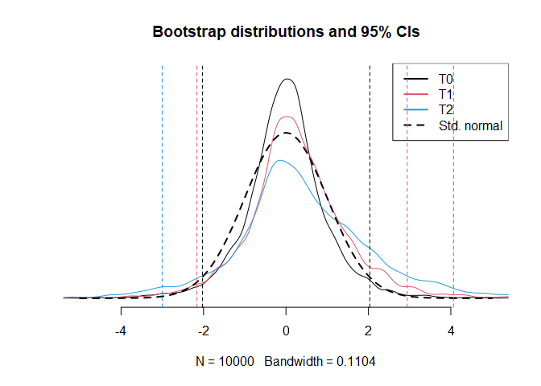

```r
T0 <- (trueB[, 2] - mean(trueB[, 2])) / sd(trueB[, 2])
T1 <- (boot1$t[, 2] - boot1$t0[2]) / sqrt(boot1$t[, 5])
T2 <- (boot2$t[, 2] - boot2$t0[2]) / sqrt(boot2$t[, 5])
den.list <- lapply(list(T0, T1, T2), density)
plot(den.list[[1]], bty = "n", main = "Bootstrap distributions and 95% CIs", ylab = "", yaxt = "n",
     ylim = range(unlist(lapply(den.list, "[[", "y")))*1.03, xlim = c(-5, 5))
lines(density(T1, adjust = 0.75), col = 2)
lines(density(T2, adjust = 0.75), col = 4)
curve(dnorm(x), add = TRUE, lty = 2, lwd = 2)
legend("topright", c(paste0("T", 0:2), "Std. normal"), col = c(1, 2, 4, 1), lwd = 2, lty = c(1, 1, 1, 2))
abline(v = quantile(T0, c(0.025, 0.975)), lty = 2)
abline(v = quantile(T1, c(0.025, 0.975)), lty = 2, col = 2)
abline(v = quantile(T2, c(0.025, 0.975)), lty = 2, col = 4)
```

### Bootstrap-t-based confidence intervals

Now, we compute the bootstrap-$t$ confidence intervals. Note that with ordinary pairwise bootstrap based on `myRegCoef`, the bootstrap-$t$ CIs cannot be computed (see the warning below):

```r
ci0 <- boot::boot.ci(boot0, index = 2)
```

```
#> Warning in boot::boot.ci(boot0, index = 2): bootstrap variances needed for
#> studentized intervals
```

```r
ci1 <- boot::boot.ci(boot1, index = c(2, 5), type = "stud")
ci2 <- boot::boot.ci(boot2, index = c(2, 5), type = "stud")
print(ci0)
```

```
#> BOOTSTRAP CONFIDENCE INTERVAL CALCULATIONS
#> Based on 1999 bootstrap replicates
#>
#> CALL :
#> boot::boot.ci(boot.out = boot0, index = 2)
#>
#> Intervals :
#> Level      Normal              Basic
#> 95%   ( 0.317,  1.596 )   ( 0.378,  1.666 )
#>
#> Level     Percentile            BCa
#> 95%   ( 0.342,  1.630 )   ( 0.211,  1.516 )
#> Calculations and Intervals on Original Scale
```

```r
print(ci1)
```

```
#> BOOTSTRAP CONFIDENCE INTERVAL CALCULATIONS
#> Based on 1999 bootstrap replicates
#>
#> CALL :
#> boot::boot.ci(boot.out = boot1, type = "stud", index = c(2, 5))
#>
#> Intervals :
#> Level    Studentized
#> 95%   ( 0.064,  1.695 )
#> Calculations and Intervals on Original Scale
```

```r
print(ci2)
```

```
#> BOOTSTRAP CONFIDENCE INTERVAL CALCULATIONS
#> Based on 1999 bootstrap replicates
#>
#> CALL :
#> boot::boot.ci(boot.out = boot2, type = "stud", index = c(2, 5))
#>
#> Intervals :
#> Level    Studentized
#> 95%   (-0.044,  1.784 )
#> Calculations and Intervals on Original Scale
```

This is how one can obtain the same intervals by hand (note the small discrepancy due to the fact that the `quantile()` functions interpolates by default, whereas with `B = 1999`, the order statistics for the 95% CI are exact):

```r
rbind(DoubleBoot = boot1$t0[2] - quantile(T1, c(0.975, 0.025)) * sqrt(boot1$t0[5]),
      AsySEBoot  = boot2$t0[2] - quantile(T2, c(0.975, 0.025)) * sqrt(boot2$t0[5]))
```

```
#>               97.5%  2.5%
#> DoubleBoot  0.06517 1.693
#> AsySEBoot  -0.04320 1.778
```

However, with $(B+1)\cdot \alpha/2$ being an integer, one may extract the order statistics with the specified indices and get identical results:

```r
rbind(DoubleBoot = boot1$t0[2] - sort(T1)[c(0.975, 0.025)*(B+1)] * sqrt(boot1$t0[5]),
      AsySEBoot  = boot2$t0[2] - sort(T2)[c(0.975, 0.025)*(B+1)] * sqrt(boot2$t0[5]))
```

```
#>                [,1]  [,2]
#> DoubleBoot  0.06412 1.695
#> AsySEBoot  -0.04385 1.784
```

Conclusion: it is yet unclear if the hypothesis about the significance of $X_1$ (equality of the coefficient on it to zero) should be rejected or not because the zero may or may not belong to the 95% bootstrap-$t$ CIs depending on the variance estimation method for pivoting.

### Bootstrap p-values

Finally, we can report the bootstrap $p$-values, and to do this, we define a small function assuming that the first half of the bootstrap result matrix columns contains point estimates and the second one contains variances:

```r
pvalBoot <- function(b, alternative = c("two.sided", "less", "greater"), mu = NULL) {
  if (class(b) != "boot") stop("The input must be the output of 'boot'.")
  alternative <- alternative[1]
  k <- length(b$t0)/2
  if (k != floor(k)) stop("The bootstrapped quantities should be (coefs, variances) of equal length.")
  if (is.null(mu)) mu <- rep(0, k)
  b.i <- 1:k
  v.i <- b.i + k
  t.obs <- (b$t0[b.i] - mu) / sqrt(b$t0[v.i]) # Is asymp. N(0, 1) under the true null
  t.star <- sweep(b$t[, b.i, drop = FALSE], 2, b$t0[b.i], "-") / sqrt(b$t[, v.i, drop = FALSE])
  s.obs  <- switch(alternative, two.sided = abs(t.obs),  greater = t.obs, less = -t.obs)
  s.star <- switch(alternative, two.sided = abs(t.star), greater = t.star, less = -t.star)
  out <- colMeans(sweep(s.star, 2, s.obs, ">="))
  names(out) <- names(b$t0[b.i])
  return(out)
}
rbind(DoubleBootP = pvalBoot(boot1), AsySEBootP = pvalBoot(boot2)) # Two-sided p-value
```

```
#>             (Intercept)      x1     x2
#> DoubleBootP     0.09055 0.02401 0.3062
#> AsySEBootP      0.08404 0.04052 0.3492
```

```r
rbind(DoubleBootP = pvalBoot(boot1, "greater"), AsySEBootP = pvalBoot(boot2, "greater")) # P(^t > tcrit)
```

```
#>             (Intercept)      x1     x2
#> DoubleBootP    0.009505 0.01751 0.2396
#> AsySEBootP     0.010005 0.03102 0.2646
```

```r
rbind(DoubleBootP = pvalBoot(boot1, "less"), AsySEBootP = pvalBoot(boot2, "less")) # P(^t < tcrit)
```

```
#>             (Intercept)     x1     x2
#> DoubleBootP      0.9905 0.9825 0.7604
#> AsySEBootP       0.9900 0.9690 0.7354
```

## Example 5: Bootstrapping arbitrary quantities of interest

Suppose that you have some estimator with nice properties (such that bootstrap does not fail and is consistent). Here is how compute the confidence intervals for it.

As an example, we take the `loess` function that produces a nearest-neighbour non-parametric estimator of $m(x) := \mathbb{E}(Y \mid X = x)$ given a sample $X_1, \ldots, X_n$. In this case, this estimator depends on the chosen value $x$: we would like to know the best predictor of $Y$ for some particular value of $X$.

We simulate a non-linear DGP and try to estimate it on a grid of points using a simple built-in function. For now, just take the expression for `loess` as granted and believe that is the very popular estimator that is correctly invoked and returns a consistent estimator of $m(X)$. This is how one realisation of such a DGP looks like:

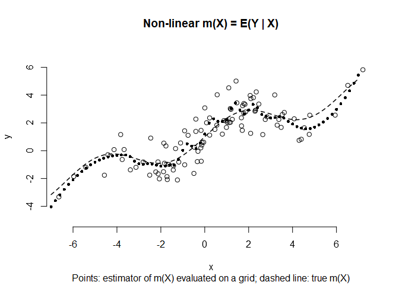

```r
set.seed(1)
x <- rnorm(100, sd = 3)
f <- function(t) 1 + 0.5*t + sin(t)
y <- f(x) + rnorm(100)
xgrid <- seq(-7, 7, 0.2)

getLoess <- function(d, i) {
  l <- loess(y ~ x, data = d[i, ], span = 0.2, control = loess.control(surface = "direct"))
  xgrid <- seq(-7, 7, 0.2)
  # xgrid exists as a global objects, but exporting them to the cluster on Windows is a waste of time
  predict(l, newdata = data.frame(x = xgrid))
}

yhat <- getLoess(data.frame(y, x), i = 1:100)
plot(x, y, ylim = c(-5, 7), bty = "n", main = "Non-linear m(X) = E(Y | X)",
     sub = "Points: estimator of m(X) evaluated on a grid; dashed line: true m(X)")
points(xgrid, yhat, pch = 16, cex = 0.7)
lines(xgrid, f(xgrid), lty = 2, lwd = 1.5)
```

This is how we bootstrap it:

```r
set.seed(2023) # It can be any seed
loess.boot <- boot(data = data.frame(x, y), statistic = getLoess, R = 999, ncpus = 4,
                   parallel = if (.Platform$OS.type == "windows") "snow" else "multicore")
dim(loess.boot$t)
```

```
#> [1] 999  71
```

The resulting matrix has as many rows as there are bootstrap replications, and as many column as the dimension of the parameter of interest. In this example, the parameter of interest is really infinite-dimensional, but we are estimating it on a grid of 71 values.

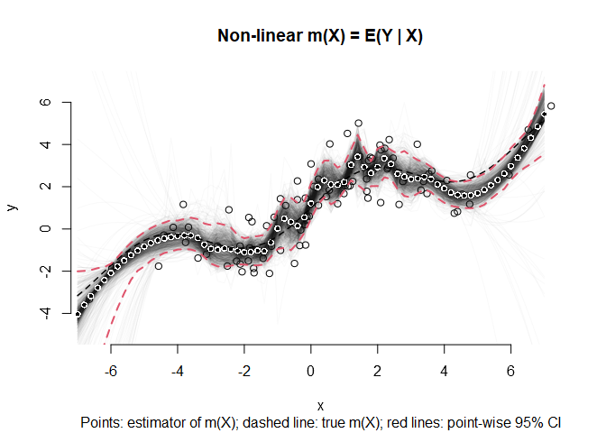

```r
plot(x, y, ylim = c(-5, 7), bty = "n", main = "Non-linear m(X) = E(Y | X)",
     sub = "Points: estimator of m(X); dashed line: true m(X); red lines: point-wise 95% CI")
for (i in 1:nrow(loess.boot$t)) lines(xgrid, loess.boot$t[i, ], col = "#00000006")
points(xgrid, yhat, pch = 16, cex = 1, col = "#FFFFFF")
points(xgrid, yhat, pch = 16, cex = 0.6)
lines(xgrid, f(xgrid), lty = 2, lwd = 1.5)
lines(xgrid, apply(loess.boot$t, 2, function(x) quantile(x, 0.025)), lwd = 2, col = 2, lty = 2)
lines(xgrid, apply(loess.boot$t, 2, function(x) quantile(x, 0.975)), lwd = 2, col = 2, lty = 2)
```

Observe that the estimator has a higher variance where the data points are sparse.

Finally, if we are not interested in estimating conditional expectations, we can simply estimate densities. Here, we illustrate the effect of the bandwidth on the bias-variance trade-off of the estimator. For this, we define the statistic as a function of one extra parameter: bandwidth `bnd`. Note that we are using the same seed and the same number of draws to have comparable bootstraps re-estimations!

We want to compare the bootstrap confidence intervals for the density estimator with 3 different bandwidths: 0.5, 1, 2. Here is how we do it efficiently:

```r
getDen <- function(d, i, bnd) density(d[i], bw = bnd, from = -7, to = 7, n = 128)$y
xdgrid <- density(x, from = -7, to = 7, n = 128)$x # This grid will be the same
system.time({res.list <- lapply(c(0.5, 1, 2), function(b) {
  cat("Doing bw =", b, "\n")
  set.seed(2024)
  boot(data = x, statistic = getDen, bnd = b, R = 999)
})})
```

```
#> Doing bw = 0.5
#> Doing bw = 1
#> Doing bw = 2
#>    user  system elapsed
#>    1.07    0.06    1.14
```

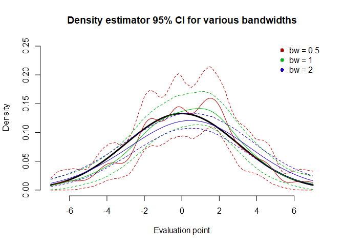

```r
names(res.list) <- c("b=0.5", "b=1", "b=2")

mycols <- rainbow(3, end = 0.7, v = 0.7)
plot(xdgrid, dnorm(xdgrid, sd = 3), bty = "n", type = "l", lwd = 3, ylim = c(0, 0.25), ylab = "Density",
     main = "Density estimator 95% CI for various bandwidths", xlab = "Evaluation point")
for (i in 1:3) {
  lines(xdgrid, res.list[[i]]$t0, col = mycols[i])
  lines(xdgrid, apply(res.list[[i]]$t, 2, quantile, prob = 0.025), col = mycols[i], lty = 2)
  lines(xdgrid, apply(res.list[[i]]$t, 2, quantile, prob = 0.975), col = mycols[i], lty = 2)
}
legend("topright", paste0("bw = ", c(0.5, 1, 2)), pch = 16, col = mycols, bty = "n")
```

As a silly exercise, we can calculate the density-weighted average CI width:

```r
den.ci.width <- sapply(res.list, function(x) {
  u <- apply(x$t, 2, quantile, prob = 0.975)
  l <- apply(x$t, 2, quantile, prob = 0.025)
  u - l
})
den.w <- dnorm(xdgrid, sd = 3); den.w <- den.w / sum(den.w)
colSums(den.ci.width * den.w)
```

```
#>   b=0.5     b=1     b=2
#> 0.08002 0.04920 0.02528
```

Conclusion: larger bandwidth = smaller variance (but potentially higher bias).

## Example 6: Bootstrapping arbitrary M-estimators

Now we consider a rather general penalty function for a rather general model.

Suppose that $Y = h(X, \theta_0) + U$, where $h$ is a non-linear function known up to the parameter $\theta_0$. We would like to estimate $\theta_0$ in two ways: assuming the parametric distribution of the model error (and therefore maximising the likelihood) and without such an assumption.

This example is remarkable due to the following extra complication: suppose that the model error $U \sim \mathrm{t}_2$ comes from a Student’s $t$ distribution with only 2 degrees of freedom; therefore, $\mathop{\mathrm{Var}} U = \infty$. This means that $\mathbb{E} U^2 = \infty$ and the standard theory does not work. Therefore, we need to minimise a penalty function of $U$ that is well-behaved and has a finite expected value. For example, we know that if $U \sim \mathrm{t}_2$, then, $\mathbb{E} |U|^p < \infty$ for $p<2$, e.g.,
$$f_{U}(t) := \frac{1}{2\sqrt{2}} \frac{1}{(1 + x^2/2)^{3/2}} \quad
\Rightarrow \quad \mathbb{E} |U| = \sqrt{2}, \quad \mathbb{E} |U|^{3/2}
= 2^{3/4} \Gamma(1/4) \Gamma(5/4) / \sqrt{\pi} \approx 3.12.$$
Also, note that the conditional variance is finite if we trim away the tails of the distribution at $\pm 5\%$ and consider the middle 90% of the distribution mass:
$$Q_{U}(0.05) \approx -2.92, \quad \mathop{\mathrm{Var}}(U \mid
Q_U(0.05)\le U\le Q_{U}(0.95)) = \int_{-2.92}^{+2.92} (t-0)^2 \cdot 10/9
\cdot f_U(t) \, \mathrm{d}t \approx 1.272.$$

```r
integrate(function(x) abs(x) * dt(x, df = 2), -Inf, Inf)
```

```
#> 1.414 with absolute error < 2.2e-09
```

```r
integrate(function(x) abs(x)^1.5 * dt(x, df = 2), -Inf, Inf)
```

```
#> 3.118 with absolute error < 8e-05
```

```r
uniroot(function(x) pt(x, df = 2) - 0.05, c(-4, -1))$root
```

```
#> [1] -2.92
```

```r
integrate(function(x) 10/9*x^2 * dt(x, df = 2), -2.92, 2.92)
```

```
#> 1.272 with absolute error < 1.2e-09
```

Now assume that
$$h(X, \theta_0) := \beta_0 + \beta_1 X^{(1)} + [X^{(2)}]^{\beta_2}$$
and the researcher knows $h$ up to the parameter $\theta_0$.

We consider 5 estimators involving $U_i(\theta) = U(\theta, Y_i, X_i) := Y_i - h(X_i, \theta)$:

1. Maximum likelihood assuming the true parametric density with an unknown number of degrees of freedom of the error distribution that is estimated: $(\hat\theta_{\mathrm{ML}}, \hat\nu_{\mathrm{ML}}) := \arg\max_{\theta,\nu} \frac1n \sum_i \log f_{Y_i \mid X_i; \theta, \nu} (Y_i) := \arg\max_{\theta, \nu} \frac1n \sum_i \ell (\theta, \nu; Y_i, X_i) = \arg\max_{\theta, \nu} \frac1n \sum_i \log f_{\mathrm{t}_\nu} (U_i(\theta))$;
2. Least absolute deviations: $\hat\theta_{\mathrm{LAD}} := \arg\min_{\theta} \frac1n \sum_i |U_i(\theta)|$;
3. M-estimator with a power-1.5 penalty higher then LAD but less than LS: $\hat\theta_{\mathrm{M}} := \arg\min_{\theta} \frac1n \sum_i |U_i(\theta)|^{3/2}$;
4. Trimmed least squares with 10% trimming (i.e. excluding the 10% largest values of squared residuals): $\hat\theta_{\mathrm{TLS}} := \arg\min_{\theta} \frac{1}{0.9n} \sum_{(i) = 1}^{0.9 n} |U_{(i)}(\theta)|^2$,
5. Non-linear least squares, $\hat\theta_{\mathrm{LS}} := \arg\min_{\theta} \frac1n \sum_i |U_i(\theta)|^2$, which is clearly wrong because $\mathbb{E} U^2 = \infty$.

Since this is a non-linear minimisation problem, we have to tackle the initial-value and local-optimum problems. There are smart brute-force methods of global optimisation (particle swarm optimisation, differential evolution etc.), but in this example, we shall apply a very simple approach: evaluate the objective function on a grid of 1000 points uniformly spaced in a reasonably sized 3D cube, and use derivative-free Nelder–Mead (default method in `optim`) from there.

Suppose that $\theta_0 = (1, 1, 0.5)$. We produce one data set on which we shall carry out the estimation:

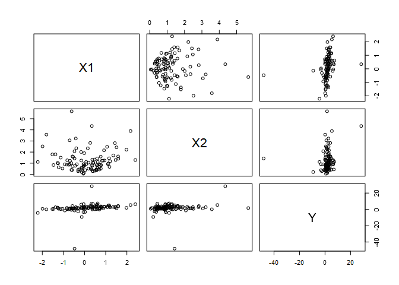

```r
set.seed(1)
X1 <- rnorm(100)
X2 <- abs(rt(100, 5)) + 0.5*abs(X1)
Y <- 1 + X1 + X2^0.5 + rt(100, 2)
d <- data.frame(X1, X2, Y)
plot(d)
```

Note the highly influential points.

Now we define the 5 penalties to be minimised – all depending on the discrepancy between the LHS and RHS. Note that the parameter vector for the ML estimator has length 4, not 3: 3 model parameters + 1 distribution parameter.

```r
U <- function(theta, data) data$Y - theta[1] - theta[2]*data$X1 - data$X2^theta[3]
lossML  <- function(theta, data) mean(dt(U(theta, data), df = theta[4], log = TRUE))
lossLAD <- function(theta, data) mean(abs(U(theta, data)))
lossM  <- function(theta, data) mean(abs(U(theta, data))^1.5)
lossTLS  <- function(theta, data) {r <- sort(U(theta, data)^2); mean(r[1:floor(0.9*length(r))])}
lossLS  <- function(theta, data) mean(U(theta, data)^2)
```

```r
set.seed(111)
par.grid <- cbind(runif(1000, 0, 2), runif(1000, 0, 2), runif(1000, 0, 1.5))
par.grid.ml <- cbind(runif(1000, 0, 2), runif(1000, 0, 2), runif(1000, 0, 1.5), runif(1000, 1, 5))
colnames(par.grid) <- paste0("b", 0:2)
colnames(par.grid.ml) <- c(paste0("b", 0:2), "df")
optML <- optim(par = par.grid.ml[which.max(apply(par.grid.ml, 1, lossML, data = d)), ],
               fn = lossML, data = d, control = list(fnscale = -1, maxit = 10000))
optLAD <- optim(par = par.grid[which.min(apply(par.grid, 1, lossLAD, data = d)), ],
               fn = lossLAD, data = d, control = list(maxit = 10000))
optM <- optim(par = par.grid[which.min(apply(par.grid, 1, lossM, data = d)), ],
               fn = lossM, data = d, control = list(maxit = 10000))
optTLS <- optim(par = par.grid[which.min(apply(par.grid, 1, lossTLS, data = d)), ],
                fn = lossTLS, data = d, control = list(maxit = 10000))
optLS <- optim(par = par.grid[which.min(apply(par.grid, 1, lossLS, data = d)), ],
               fn = lossLS, data = d, control = list(maxit = 10000))
print(cbind(ML = optML$par, LAD = c(optLAD$par, NA), Pow1.5 = c(optM$par, NA),
            TLS = c(optTLS$par, NA), LS = c(optLS$par, NA)))
```

```
#>        ML    LAD Pow1.5    TLS    LS
#> b0 0.9244 0.8683 0.8065 0.7887 0.181
#> b1 1.0888 1.1269 1.2118 1.1303 1.641
#> b2 0.2457 0.2059 0.5064 0.3085 1.171
#> df 1.4497     NA     NA     NA    NA
```

In theory, the ML estimator should beat all other estimators because the specification is correct and it should be the best unbiased estimator. Let us estimate the distributions of these estimators using bootstrap, and we should always time the evaluation because we need to estimate the approximate run time of the bootstrap:

```r
compare5 <- function(d, i) {
  boot.d <- d[i, ]
  optML <- optim(par = par.grid.ml[which.max(apply(par.grid.ml, 1, lossML, data = boot.d)), ],
                 fn = lossML, data = boot.d, control = list(fnscale = -1, maxit = 10000))
  optLAD <- optim(par = par.grid[which.min(apply(par.grid, 1, lossLAD, data = boot.d)), ],
                  fn = lossLAD, data = boot.d, control = list(maxit = 10000))
  optM <- optim(par = par.grid[which.min(apply(par.grid, 1, lossM, data = boot.d)), ],
                 fn = lossM, data = boot.d, control = list(maxit = 10000))
  optTLS <- optim(par = par.grid[which.min(apply(par.grid, 1, lossTLS, data = boot.d)), ],
                  fn = lossTLS, data = boot.d, control = list(maxit = 10000))
  optLS <- optim(par = par.grid[which.min(apply(par.grid, 1, lossLS, data = boot.d)), ],
                 fn = lossLS, data = boot.d, control = list(maxit = 10000))
  c(optML$par, optLAD$par, optM$par, optTLS$par, optLS$par)
}
system.time(compare5(d, 1:nrow(d)))
```

```
#>    user  system elapsed
#>    0.23    0.00    0.23
```

```r
if (.Platform$OS.type == "windows") {
  cl <- parallel::makeCluster(cores, type = "PSOCK")
  parallel::clusterExport(cl, c("d", "par.grid", "par.grid.ml", "U", "compare5",
                                "lossML", "lossLAD", "lossM", "lossTLS", "lossLS"))
  set.seed(1)
  system.time(boot.nl <- boot(d, compare5, R = 999, cl = cl, parallel = "snow", ncpus = cores))
  parallel::stopCluster(cl)
} else {
  set.seed(1)
  system.time(boot.nl <- boot(d, compare5, R = 999, parallel = "multicore", ncpus = cores))
}
```

This is almost magic: parallel computations are so much faster!

Now, recall that we are estimating the vector of interest using 5 methods, therefore, here, the returned statistic is really $(\hat\theta^*_{\mathrm{ML}}, \hat\theta^*_{\mathrm{LAD}}, \hat\theta^*_{\mathrm{M}}, \hat\theta^*_{\mathrm{TLS}}, \hat\theta^*_{\mathrm{LS}})_{(4+3+3+3+3)\times 1}$.

```r
theta.nl <- boot.nl$t
colnames(theta.nl) <- c(paste0("b", 0:2, ".ML"), "df.ML", paste0("b", 0:2, ".LAD"),
                        paste0("b", 0:2, ".M"), paste0("b", 0:2, ".TLS"), paste0("b", 0:2, ".LS"))
summary(theta.nl[, 1:4])
```

```
#>      b0.ML           b1.ML           b2.ML            df.ML
#>  Min.   :0.489   Min.   :0.647   Min.   :-0.299   Min.   :0.94
#>  1st Qu.:0.833   1st Qu.:0.988   1st Qu.: 0.177   1st Qu.:1.31
#>  Median :0.920   Median :1.090   Median : 0.249   Median :1.47
#>  Mean   :0.917   Mean   :1.089   Mean   : 0.250   Mean   :1.53
#>  3rd Qu.:1.003   3rd Qu.:1.187   3rd Qu.: 0.322   3rd Qu.:1.68
#>  Max.   :1.308   Max.   :1.895   Max.   : 0.641   Max.   :3.79
```

```r
summary(theta.nl[, 4 + 1:3])
```

```
#>      b0.LAD          b1.LAD          b2.LAD
#>  Min.   :0.410   Min.   :0.545   Min.   :-0.211
#>  1st Qu.:0.786   1st Qu.:1.026   1st Qu.: 0.165
#>  Median :0.856   Median :1.121   Median : 0.224
#>  Mean   :0.872   Mean   :1.135   Mean   : 0.260
#>  3rd Qu.:0.949   3rd Qu.:1.241   3rd Qu.: 0.320
#>  Max.   :1.409   Max.   :1.814   Max.   : 1.091
```

```r
summary(theta.nl[, 7 + 1:3])
```

```
#>       b0.M             b1.M            b2.M
#>  Min.   :-0.249   Min.   :0.559   Min.   :-0.374
#>  1st Qu.: 0.609   1st Qu.:1.098   1st Qu.: 0.320
#>  Median : 0.775   Median :1.232   Median : 0.511
#>  Mean   : 0.747   Mean   :1.235   Mean   : 0.611
#>  3rd Qu.: 0.897   3rd Qu.:1.363   3rd Qu.: 0.767
#>  Max.   : 1.408   Max.   :2.116   Max.   : 2.187
```

```r
summary(theta.nl[, 10 + 1:3])
```

```
#>      b0.TLS          b1.TLS          b2.TLS
#>  Min.   :0.212   Min.   :0.582   Min.   :-0.364
#>  1st Qu.:0.743   1st Qu.:0.941   1st Qu.: 0.199
#>  Median :0.867   Median :1.081   Median : 0.297
#>  Mean   :0.860   Mean   :1.082   Mean   : 0.290
#>  3rd Qu.:0.984   3rd Qu.:1.215   3rd Qu.: 0.392
#>  Max.   :1.486   Max.   :1.857   Max.   : 0.696
```

```r
summary(theta.nl[, 13 + 1:3])
```

```
#>      b0.LS            b1.LS           b2.LS
#>  Min.   :-2.470   Min.   :0.156   Min.   :-0.784
#>  1st Qu.:-0.265   1st Qu.:1.308   1st Qu.: 0.457
#>  Median : 0.227   Median :1.600   Median : 1.149
#>  Mean   : 0.117   Mean   :1.643   Mean   : 0.987
#>  3rd Qu.: 0.631   3rd Qu.:1.924   3rd Qu.: 1.493
#>  Max.   : 1.397   Max.   :3.838   Max.   : 2.166
```

No serious issues here, therefore, we can visualise the results.

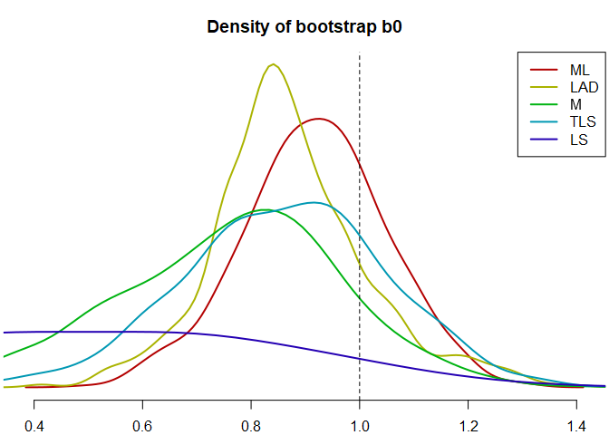

```r
mycols <- rainbow(5, end = 0.7, v = 0.7)
dens <- apply(theta.nl, 2, density, bw = "SJ", n = 128)

par(mar = c(2, 0.2, 3, 0.2))
vn <- c("LAD", "M", "TLS", "LS")
plot(dens[["b0.ML"]]$x, dens[["b0.ML"]]$y, main = "Density of bootstrap b0", type = "l", bty = "n", ylab = "",
     xlab = "", lwd = 2, col = mycols[1], yaxt = "n", ylim = c(0, max(dens[["b0.ML"]]$y * 1.2)))
for (i in 1:4) lines(dens[[paste0("b0.", vn[i])]], col = mycols[i+1], lwd = 2)
abline(v = 1, lty = 2)
legend("topright", c("ML", vn), col = mycols, lwd = 2)
```

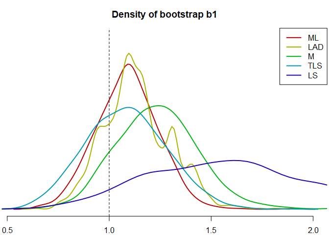

```r
plot(dens[["b1.ML"]]$x, dens[["b1.ML"]]$y, main = "Density of bootstrap b1", type = "l", bty = "n", ylab = "",
     xlab = "", lwd = 2, col = mycols[1], yaxt = "n", ylim = c(0, max(dens[["b1.ML"]]$y * 1.2)))
for (i in 1:4) lines(dens[[paste0("b1.", vn[i])]], col = mycols[i+1], lwd = 2)
abline(v = 1, lty = 2)
legend("topright", c("ML", vn), col = mycols, lwd = 2)
```

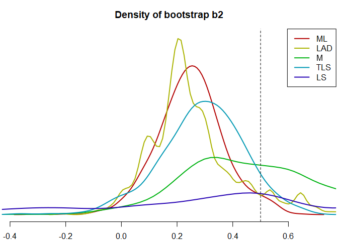

```r
plot(dens[["b2.ML"]]$x, dens[["b2.ML"]]$y, main = "Density of bootstrap b2", type = "l", bty = "n", ylab = "",
     xlab = "", lwd = 2, col = mycols[1], yaxt = "n", ylim = c(0, max(dens[["b2.ML"]]$y * 1.2)))
for (i in 1:4) lines(dens[[paste0("b2.", vn[i])]], col = mycols[i+1], lwd = 2)
abline(v = 0.5, lty = 2)
legend("topright", c("ML", vn), col = mycols, lwd = 2)
```

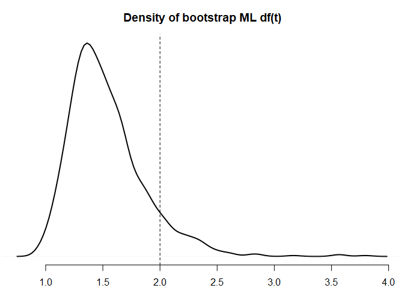

```r
plot(dens[["df.ML"]], main = "Density of bootstrap ML df(t)", bty = "n", ylab = "", xlab = "", lwd = 2, yaxt = "n")
abline(v = 2, lty = 2)
```

## Example 7: Bootstrap failure

Classical example where bootstrap fails: the ML estimator of the sample maximum (the `German tank’ problem). It fails because its rate of convergence is $n$, not $\sqrt{n}$.

```r
trueM <- sapply(1:10000, function(s) {
  set.seed(s)
  if (s %% 2000 == 0) print(s)
  max(runif(20, min = 0, max = 10))
})
```

```
#> [1] 2000
#> [1] 4000
#> [1] 6000
#> [1] 8000
#> [1] 10000
```

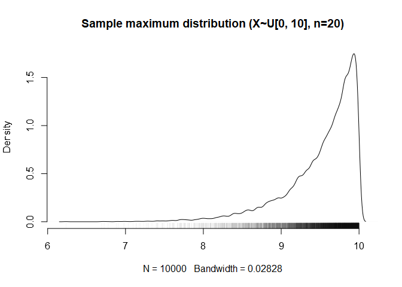

```r
plot(density(trueM, adjust = 0.5), main = "Sample maximum distribution (X~U[0, 10], n=20)", bty = "n")
rug(trueM, col = "#00000011")
```

Now we have only one data realisation, only a sample of size $n=20$ observations, and we bootstrap $X_{(n)}$, although we shouldn’t:

```r
set.seed(1)
d <- runif(20, max = 10)
print(sort(d), 3)
```

```
#>  [1] 0.618 1.766 2.017 2.060 2.655 3.721 3.800 3.841 4.977 5.729 6.291 6.608
#> [13] 6.870 7.176 7.698 7.774 8.984 9.082 9.447 9.919
```

```r
smpMax <- function(d, i) max(d[i])
set.seed(2)
unif.boot <- boot(d, smpMax, R = 9999, ncpus = 4,
                  parallel = if (.Platform$OS.type == "windows") "snow" else "multicore")
```

And here we see that the bootstrap distribution of $X^*_{(n)}$ is vastly different from the extreme-value distribution of $X_{(n)}$ (studentised):

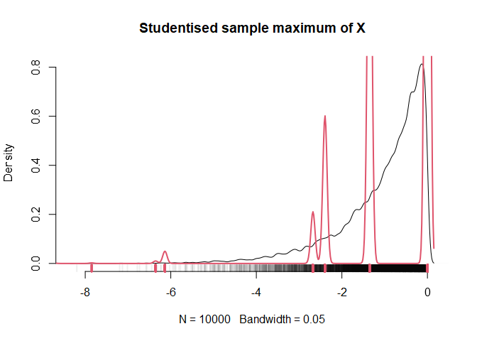

```r
that <- (trueM - 10) / sd(trueM)
tstar <- (unif.boot$t[, 1] - unif.boot$t0) / sd(unif.boot$t[, 1])
plot(density(that, bw = 0.05), main = "Studentised sample maximum of X", bty = "n")
rug(that, lwd = 2, col = "#00000011")
lines(density(tstar, bw = 0.05), col = 2, lwd = 2)
rug(tstar, col = 2, lwd = 3)
```